# Q3

Huiyan Li

3/29/2020

### **A. when n = 2, $X ∼ Unif[0, 1]$**

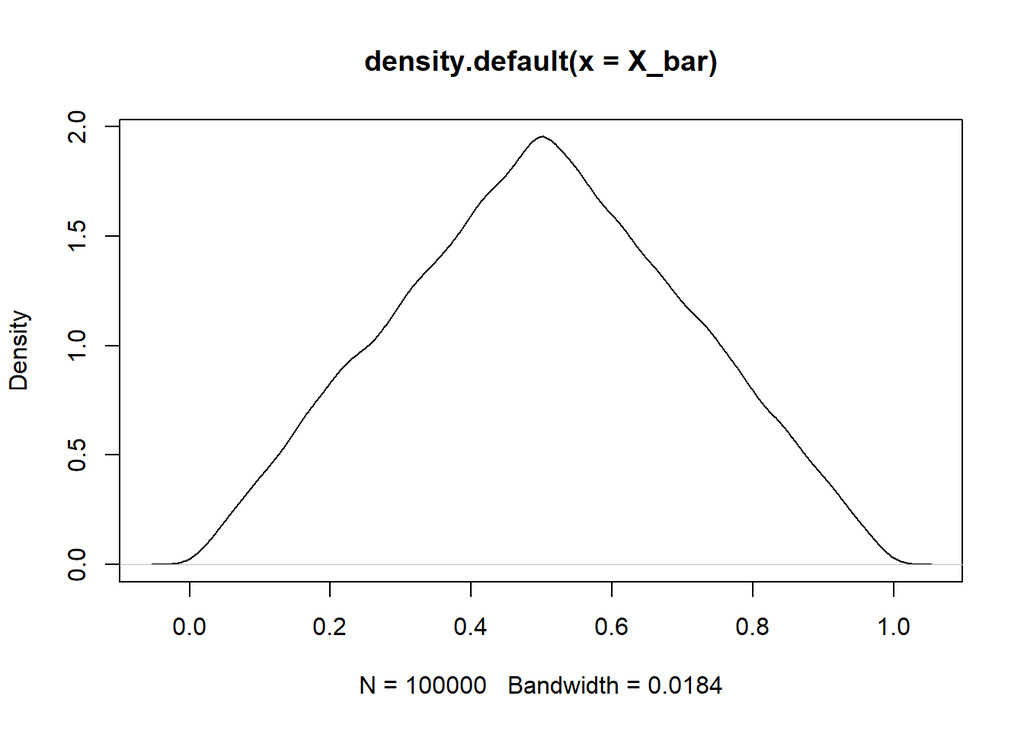

```r
sample_4m_normal = function(x) {
  s = runif(2, min = 0, max = 1)
  return (mean(s))
}
X_bar = replicate(100000, sample_4m_normal())
plot(density(X_bar))
```

### **B. when n = 5, $X ∼ Unif[0, 1]$**

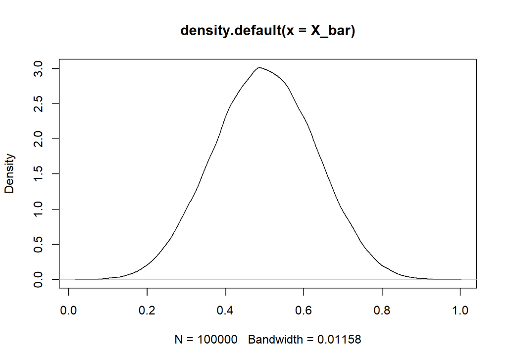

```r
sample_4m_normal = function(x) {
  s = runif(5, min = 0, max = 1)
  return (mean(s))
}
X_bar = replicate(100000, sample_4m_normal())
plot(density(X_bar))
```

### **C. when n = 5, $X ∼ x^{2}_{df = 2}$**

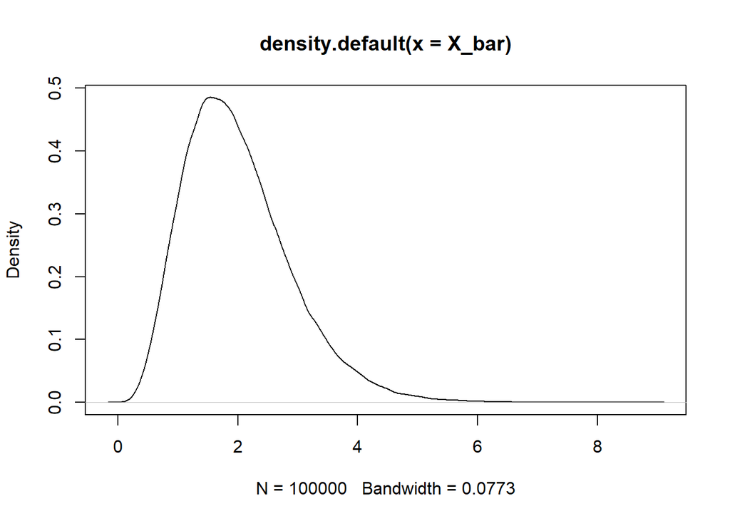

```r
sample_4m_normal = function(x) {
  s = rchisq(5, 2)
  return (mean(s))
}
X_bar = replicate(100000, sample_4m_normal())
plot(density(X_bar))
```

### **D. when n = 30, $X ∼ x^{2}_{df = 2}$**

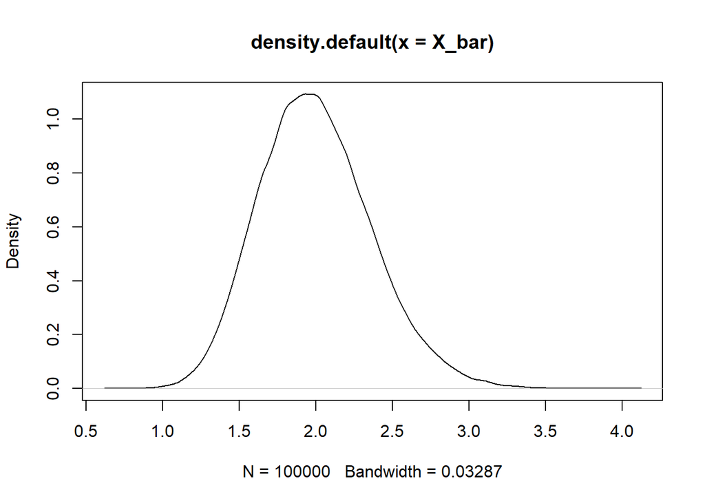

```r
sample_4m_normal = function(x) {
  s = rchisq(30, 2)
  return (mean(s))
}
X_bar = replicate(100000, sample_4m_normal())
plot(density(X_bar))
```

### **E. when n = 5, $X ∼ x^{2}_{df = 50}$**

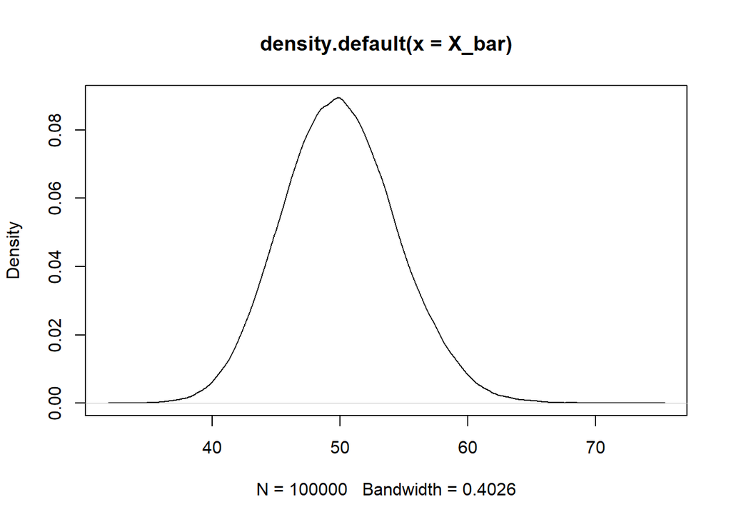

```r
sample_4m_normal = function(x) {
  s = rchisq(5, 50)
  return (mean(s))
}
X_bar = replicate(100000, sample_4m_normal())
plot(density(X_bar))
```

### **F. CLT says for large n, $\overline{X}$ converges (in distribution) to a Normal distribution**

By comparing your graphs from parts (a) to (e), can you comment on how large n has to be in order for $\overline{X}$ to converge to a Normal distribution.

### **G. Plot three separate density curves for $Unif[0, 1], χ^{2}_{df = 2}$ and $X^{2}_{df = 50}$**

Looking at the skewness of these three curves, what comments can you make on the question asked in part(f)?

$Unif[0, 1]$

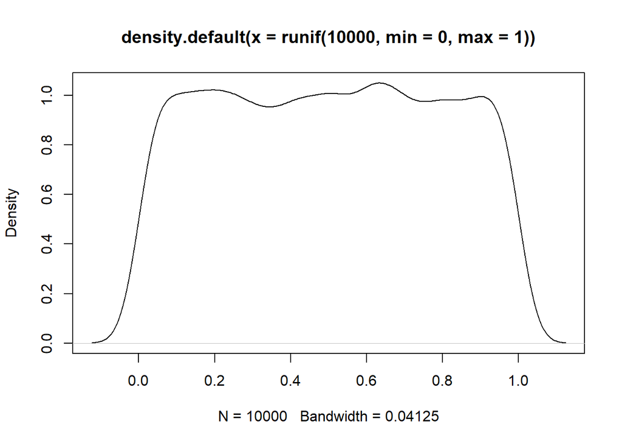

```r
plot(density(runif(10000, min = 0, max = 1)))
```

$χ^{2}_{df = 2}$

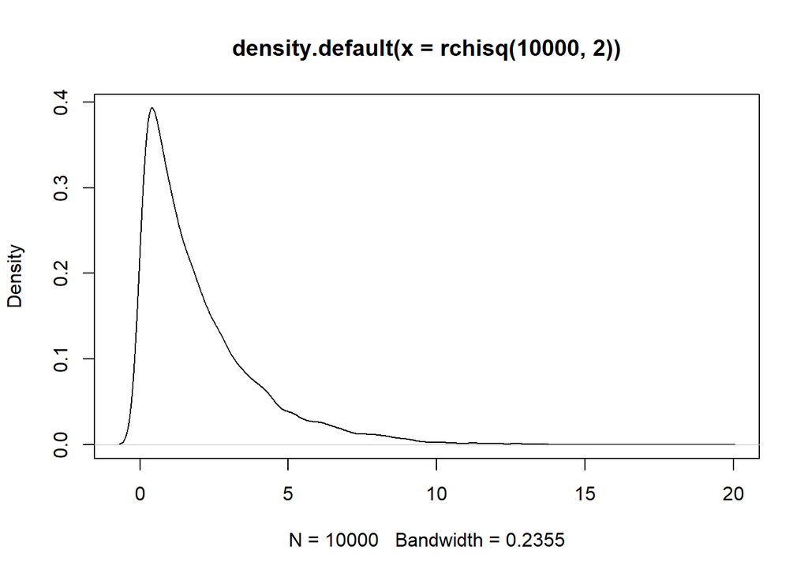

```r
plot(density(rchisq(10000, 2)))
```

$χ^{2}_{df = 50}$

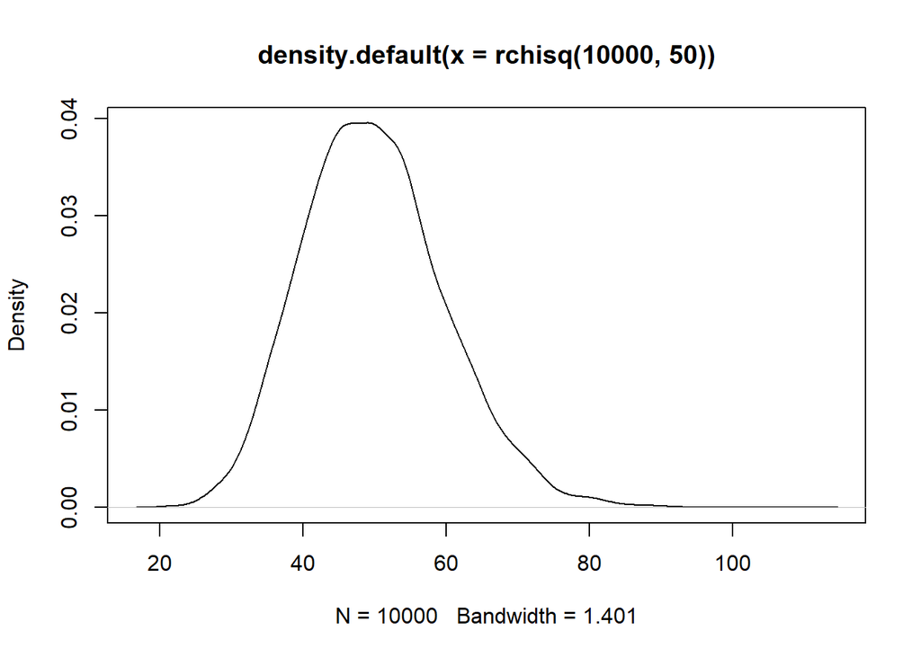

```r
plot(density(rchisq(10000, 50)))
```

From these graphs, we can see that the density graph indeed shows the density coverge to a normal distribution shape as the sample size gets larger, however, the skewness of these density graphs also indicates how quickly one can converge to a normal distribution, as it shows where the value are distributed.